# Bitácora 3

2023-10-29

Primeramente, se cargan los datos automáticamente desde una ubicación fija, así como verificar que se encuentra en formato tidy.

```r
library(readr)
library(dplyr)
```

```r
library(tidyr)
library(ggplot2)
datos <- read.csv("heart_2020_cleaned.csv", sep = ",", dec = ".")
str(datos) #Verificando que cada variable tenga su tipo correspondiente
```

```
## 'data.frame':    319795 obs. of  18 variables:
##  $ HeartDisease    : chr  "No" "No" "No" "No" ...
##  $ BMI             : num  16.6 20.3 26.6 24.2 23.7 ...
##  $ Smoking         : chr  "Yes" "No" "Yes" "No" ...
##  $ AlcoholDrinking : chr  "No" "No" "No" "No" ...
##  $ Stroke          : chr  "No" "Yes" "No" "No" ...
##  $ PhysicalHealth  : num  3 0 20 0 28 6 15 5 0 0 ...
##  $ MentalHealth    : num  30 0 30 0 0 0 0 0 0 0 ...
##  $ DiffWalking     : chr  "No" "No" "No" "No" ...
##  $ Sex             : chr  "Female" "Female" "Male" "Female" ...
##  $ AgeCategory     : chr  "55-59" "80 or older" "65-69" "75-79" ...
##  $ Race            : chr  "White" "White" "White" "White" ...
##  $ Diabetic        : chr  "Yes" "No" "Yes" "No" ...
##  $ PhysicalActivity: chr  "Yes" "Yes" "Yes" "No" ...
##  $ GenHealth       : chr  "Very good" "Very good" "Fair" "Good" ...
##  $ SleepTime       : num  5 7 8 6 8 12 4 9 5 10 ...
##  $ Asthma          : chr  "Yes" "No" "Yes" "No" ...
##  $ KidneyDisease   : chr  "No" "No" "No" "No" ...
##  $ SkinCancer      : chr  "Yes" "No" "No" "Yes" ...
```

```r
View(datos)
```

## Análisis Descriptivo de los datos

A continuación se presentará el análisis descriptivo de los datos que rodeen la pregunta de investigación por medio de gráficos y cuadros con el fin de comprender y resumir los datos de forma visual.

#### Distribución de nivel de IMC en adultos estadounidenses en 2020

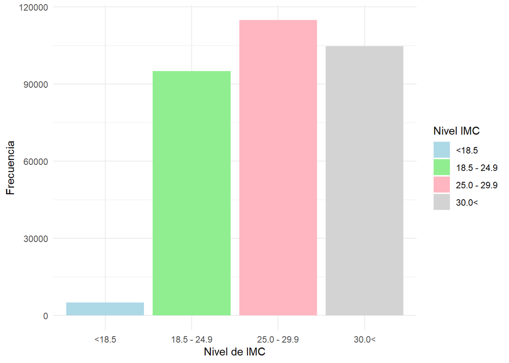

```r
bmicat <- datos$BMI %>% cut(datos$BMI,
                       breaks = c(0, 18.5, 24.9, 29.9, Inf),
                       labels = c("<18.5", "18.5 - 24.9", "25.0 - 29.9", "30.0<"),
                       right = FALSE)

distimc <- ggplot(datos, aes(x = bmicat, fill = bmicat)) +
  geom_bar() +
  labs(x = "Nivel de IMC", y = "Frecuencia",fill = "Nivel IMC") +
  scale_fill_manual(values = c("lightblue", "lightgreen", "lightpink", "lightgray")) +
  theme_minimal()
print(distimc)
```

Se puede observar que la mayoría de la población estadounidense tiene un IMC mayor a 25, esto nos indica que un porcentaje significativo tiene un IMC bastante alto, lo que es probable que se encuentren en estado de sobrepeso. Por otra parte, el porcentaje de población con IMC menor a 18.5 es muy pequeño y se nota una gran diferencia entre la frecuencia del nivel de bajo peso y la del peso adecuado.

#### Frecuencia de tabaquismo en adultos estadounidenses en 2020

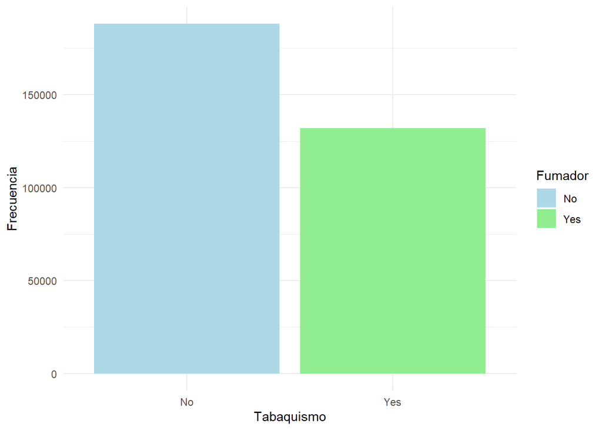

```r
distimc <- ggplot(datos, aes(x = Smoking, fill = Smoking)) +
  geom_bar() +
  labs(x = "Tabaquismo", y = "Frecuencia",fill = "Fumador") +
  scale_fill_manual(values = c("lightblue", "lightgreen")) +
  theme_minimal()
print(distimc)
```

En este gráfico podemos observar como se divide la población entre fumadores y no fumadores. En particular, se observa que la mayoría de la población no fuma; sin embargo, de igual manera el porcentaje de fumadores no es insignificante ya que igual tiene bastante frecuencia en la población.

#### Frecuencia de alcoholismo en adultos estadounidenses en 2020

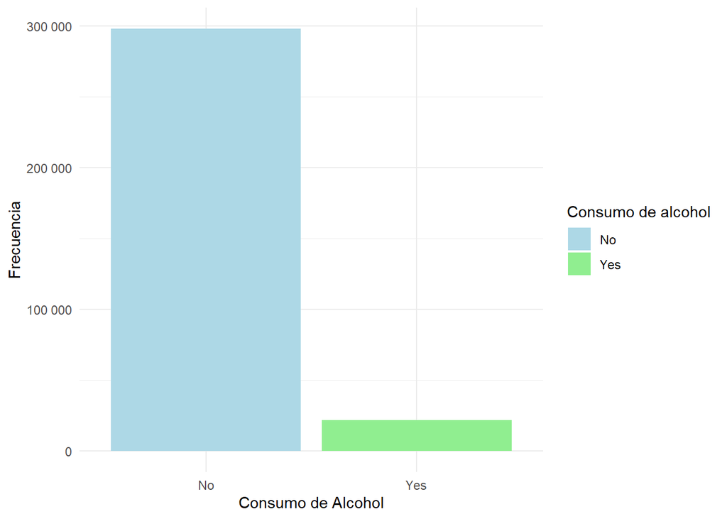

```r
distimc <- ggplot(datos, aes(x = AlcoholDrinking, fill =  AlcoholDrinking)) +
  geom_bar() +
  labs(x = "Consumo de Alcohol", y = "Frecuencia",fill = "Consumo de alcohol") +
  scale_fill_manual(values = c("lightblue", "lightgreen")) +
  theme_minimal()
print(distimc + scale_y_continuous(labels = scales::number_format(accuracy = 1)))
```

A diferencia del tabaco, existe una brecha grande entre el porcentaje de personas que ingieren alcohol y las que no. En esta población en específico, alrededor del 90% de la población se considera no alcohólica. Estos resultados van en dirección contraria a lo esperado ya que, por lo general, el consumo de alcohol está bastante normalizado y se esperaría que el porcentaje de personas que toman alcohol sea mucho mayor.

#### Frecuencia de actividad física en adultos estadounidenses en 2020

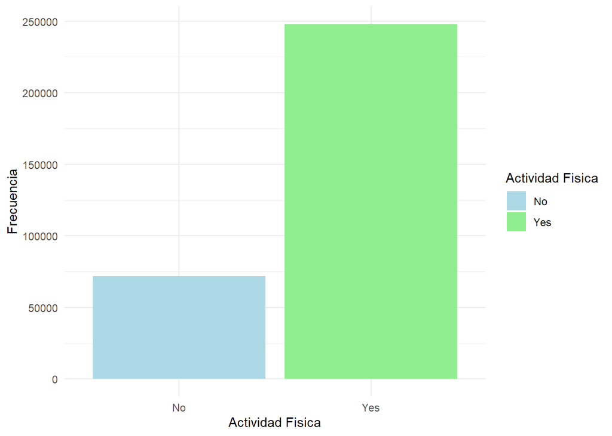

```r
distimc <- ggplot(datos, aes(x = PhysicalActivity, fill = PhysicalActivity)) +
  geom_bar() +
  labs(x = "Actividad Fisica", y = "Frecuencia",fill = "Actividad Fisica") +
  scale_fill_manual(values = c("lightblue", "lightgreen")) +
  theme_minimal()
print(distimc)
```

El gráfico señala que alrededor de un 75% (aproximadamente) de la población estudiada realiza actividad física, esto es un indicador importante ya que se conoce que la actividad física puede afectar en la salud general de las personas.

#### Índice de masa corporal y padecimiento de enfermedad cardíaca en adultos estadounidenses en 2020

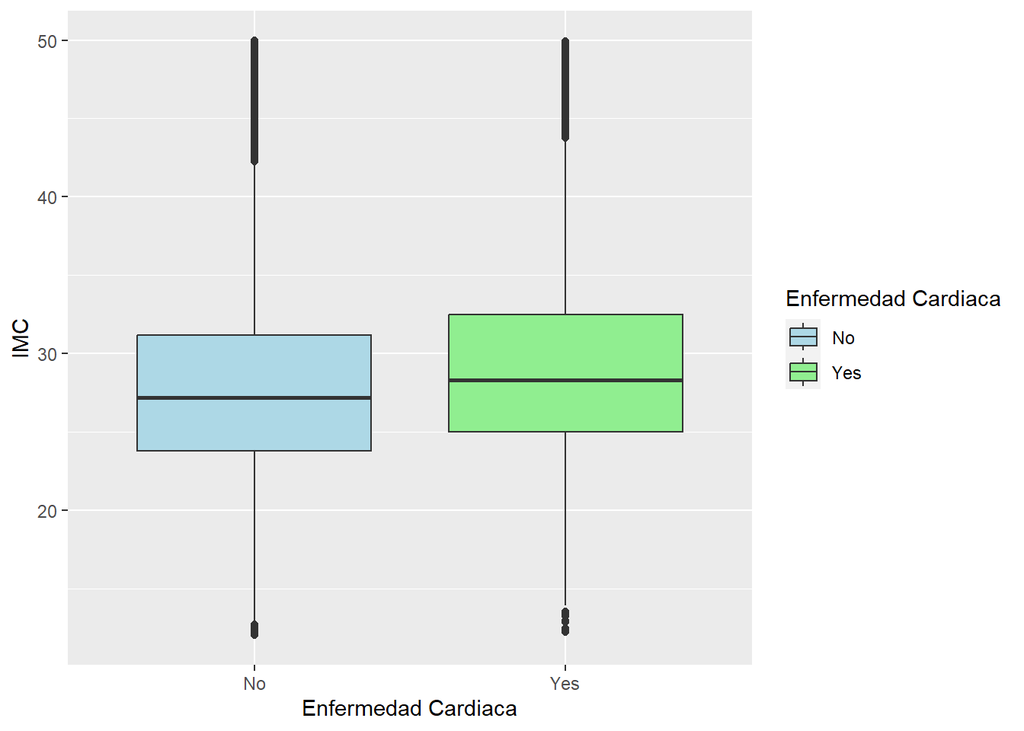

```r
datos_filtrados <- datos[datos$BMI < 50, ]
BMICardiaca <- ggplot(datos_filtrados, aes(x = HeartDisease, y = BMI, fill = HeartDisease)) +
  geom_boxplot() +
  labs(x = "Enfermedad Cardiaca", y = "IMC", fill= "Enfermedad Cardiaca") +
  scale_fill_manual(values = c("lightblue", "lightgreen"))

print(BMICardiaca)
```

El gráfico anterior es una visión rápida de la distribución de los datos y es útil para identificar valores atípicos. Observemos a continuación, la diferencia con respecto a derrame cerebral:

#### Índice de masa corporal y presencia de derrame cerebral en adultos estadounidenses en 2020

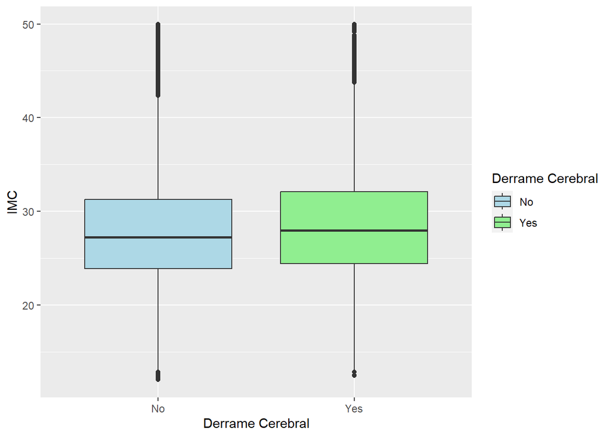

```r
BMI_Cerebral <- ggplot(datos_filtrados, aes(x = Stroke, y = BMI, fill = Stroke)) +
  geom_boxplot() +
  labs(x = "Derrame Cerebral", y = "IMC",fill = "Derrame Cerebral") +
  scale_fill_manual(values = c("lightblue", "lightgreen"))

print(BMI_Cerebral)
```

Dados estos últimos dos gráficos, se puede determinar que existe una diferencia entre la mediana de IMC de la población que, sí presenta enfermedades cardiovasculares, con respecto a las que no, además esta diferencia es más significativa en enfermedad cardíaca que en el caso de derrames cerebrales.

## Metodología

### Prueba Chi Cuadrado y tablas de contingencia

```r
datos <- datos %>%
          mutate(CardVasc = ifelse(HeartDisease == "Yes"| Stroke == "Yes", "Yes", "No"))

#Definiendo las variables de interés de la investigación
variables_de_interes <- c("Smoking", "AlcoholDrinking", "PhysicalHealth", "Sex","AgeCategory")

test <- function(var){
#Construyendo las tablas de contingencia con respecto a las variables que corresponden a enfermedades cardiovasculares
tabla_heart <- table(datos$HeartDisease, datos[[var]])
tabla_stroke <- table(datos$Stroke, datos[[var]])
tabla_cardvasc <- table(datos$CardVasc, datos[[var]])

cat("\nTabla de contingencia para HeartDisease y", var, ":\n")
print(tabla_heart)


chi2_heart <- chisq.test(tabla_heart)
print(chi2_heart)

cat("\nTabla de contingencia para Stroke y", var, ":\n")
print(tabla_stroke)

chi2_stroke <- chisq.test(tabla_stroke)
print(chi2_stroke)

cat("\nTabla de contingencia para CardVasc y", var, ":\n")
print(tabla_cardvasc)

chi2_cardvasc <- chisq.test(tabla_cardvasc)
print(chi2_cardvasc)
}


for (variable in variables_de_interes) {
  test(variable)}
```

```
##
## Tabla de contingencia para HeartDisease y Smoking :
##
##           No    Yes
##   No  176551 115871
##   Yes  11336  16037
##
##  Pearson's Chi-squared test with Yates' continuity correction
##
## data:  tabla_heart
## X-squared = 3713, df = 1, p-value < 2.2e-16
##
##
## Tabla de contingencia para Stroke y Smoking :
##
##           No    Yes
##   No  182633 125093
##   Yes   5254   6815
##
##  Pearson's Chi-squared test with Yates' continuity correction
##
## data:  tabla_stroke
## X-squared = 1198.1, df = 1, p-value < 2.2e-16
##
##
## Tabla de contingencia para CardVasc y Smoking :
##
##           No    Yes
##   No  172959 111783
##   Yes  14928  20125
##
##  Pearson's Chi-squared test with Yates' continuity correction
##
## data:  tabla_cardvasc
## X-squared = 4244.4, df = 1, p-value < 2.2e-16
##
##
## Tabla de contingencia para HeartDisease y AlcoholDrinking :
##
##           No    Yes
```

[output cut: 35 more lines]

```
##            0      1      2      3      4      5      6      7      8      9
##   No  212167   9884  13711   7774   3974   6710   1097   4164    804    143
##   Yes  14422    605   1169    843    494    896    173    465    120     37
##
##           10     11     12     13     14     15     16     17     18     19
##   No    4615     76    501     81   2581   4082    114     89    134     26
##   Yes    838      9    104     10    312    930     21     21     33      9
##
##           20     21     22     23     24     25     26     27     28     29
##   No    2575    527     74     34     52    910     54     96    338    145
##   Yes    641     99     15     12     15    254     12     28    108     59
##
##           30
##   No   14890
##   Yes   4619
```

```
##
##  Pearson's Chi-squared test
##
## data:  tabla_heart
## X-squared = 9735.6, df = 30, p-value < 2.2e-16
##
##
## Tabla de contingencia para Stroke y PhysicalHealth :
##
##            0      1      2      3      4      5      6      7      8      9
##   No  220811  10191  14373   8241   4262   7205   1191   4386    865    173
##   Yes   5778    298    507    376    206    401     79    243     59      7
##
##           10     11     12     13     14     15     16     17     18     19
##   No    5056     81    556     85   2723   4545    121    104    151     29
##   Yes    397      4     49      6    170    467     14      6     16      6
##
##           20     21     22     23     24     25     26     27     28     29
##   No    2853    575     80     44     57   1037     57    111    392    167
##   Yes    363     51      9      2     10    127      9     13     54     37
##
##           30
##   No   17204
##   Yes   2305
```

```
##
##  Pearson's Chi-squared test
##
## data:  tabla_stroke
## X-squared = 6259.1, df = 30, p-value < 2.2e-16
##
##
## Tabla de contingencia para CardVasc y PhysicalHealth :
##
##            0      1      2      3      4      5      6      7      8      9
##   No  208094   9676  13366   7537   3854   6455   1054   4013    773    140
##   Yes  18495    813   1514   1080    614   1151    216    616    151     40
##
##           10     11     12     13     14     15     16     17     18     19
##   No    4392     74    483     78   2475   3807    106     87    124     22
##   Yes   1061     11    122     13    418   1205     29     23     43     13
##
##           20     21     22     23     24     25     26     27     28     29
##   No    2368    497     67     34     47    840     50     87    312    126
##   Yes    848    129     22     12     20    324     16     37    134     78
##
##           30
##   No   13704
##   Yes   5805
```

```
##
##  Pearson's Chi-squared test
##
## data:  tabla_cardvasc
## X-squared = 12391, df = 30, p-value < 2.2e-16
##
##
## Tabla de contingencia para HeartDisease y Sex :
##
##       Female   Male
##   No  156571 135851
##   Yes  11234  16139
##
##  Pearson's Chi-squared test with Yates' continuity correction
##
## data:  tabla_heart
## X-squared = 1568.3, df = 1, p-value < 2.2e-16
##
##
## Tabla de contingencia para Stroke y Sex :
##
##       Female   Male
##   No  161378 146348
##   Yes   6427   5642
##
##  Pearson's Chi-squared test with Yates' continuity correction
##
## data:  tabla_stroke
## X-squared = 3.0231, df = 1, p-value = 0.08209
##
##
## Tabla de contingencia para CardVasc y Sex :
##
##       Female   Male
##   No  152155 132587
##   Yes  15650  19403
##
##  Pearson's Chi-squared test with Yates' continuity correction
##
## data:  tabla_cardvasc
```

[output cut: 34 more lines]

```
##
## Tabla de contingencia para CardVasc y AgeCategory :
##
##       18-24 25-29 30-34 35-39 40-44 45-49 50-54 55-59 60-64 65-69 70-74 75-79
##   No  20892 16748 18426 20091 20299 20750 23549 26817 29434 28957 25042 16392
##   Yes   172   207   327   459   707  1041  1833  2940  4252  5194  6023  5090
##
##       80 or older
##   No        17345
##   Yes        6808
##
##  Pearson's Chi-squared test
##
## data:  tabla_cardvasc
## X-squared = 23500, df = 12, p-value < 2.2e-16
```

### Prueba Wilcoxon-Mann-Whitney

```r
#Se acomodan los datos con tal de analizar dos variables, en este caso IMC-enfermedad cardíaca y IMC-derrame cerebral

BMI_Yes_HeartDisease <- datos$BMI[datos$HeartDisease == "Yes"]

BMI_No_HeartDisease <- datos$BMI[datos$HeartDisease == "No"]

BMI_Yes_Stroke <- datos$BMI[datos$Stroke == "Yes"]

BMI_No_Stroke <- datos$BMI[datos$Stroke == "No"]

#Se aplica la prueba de Wilcoxon-Mann-Whitney
wilcox.test(BMI_Yes_HeartDisease, BMI_No_HeartDisease)
```

```
##
##  Wilcoxon rank sum test with continuity correction
##
## data:  BMI_Yes_HeartDisease and BMI_No_HeartDisease
## W = 4475945990, p-value < 2.2e-16
## alternative hypothesis: true location shift is not equal to 0
```

```r
wilcox.test(BMI_Yes_Stroke, BMI_No_Stroke)
```

```
##
##  Wilcoxon rank sum test with continuity correction
##
## data:  BMI_Yes_Stroke and BMI_No_Stroke
## W = 1978474188, p-value < 2.2e-16
## alternative hypothesis: true location shift is not equal to 0
```

Si bien esta prueba es valiosa para analizar el indice de masa corporal con respecto las variables que representan la presencia de enfermedades cardiovasculares, es decir, enfermedad cardiaca y derrame cerebral, no se puede utilizar para comparar dos variables categóricas en sí. Por esta razón, no permite evaluar las demás variables de interés (Smoking, AlcoholDrinking, PhysicalActivity, AgeCategory, Sex) por lo que solo responde parcialmente a la pregunta de investigación. Por otra parte, se puede decir que se rechaza la hipótesis nula dado que el p-valor es tan pequeño, es decir, que hay una asociación significativa entre las dos variables analizadas. Esta es una prueba no paramétrica, por lo que no hay necesidad de ajustar el modelo.

### Test exacto de Fisher

Se deben crear tablas de contingencia 2x2 con cada una de las variables de estudio para poder aplicar el test.

```r
#Tablas de contingencia de tabaquismo con enfermedad cardiaca y derrame cerebral
HD_Smoke <- table(datos$HeartDisease, datos$Smoking, dnn = c("Enfermedad Cardiaca", "Tabaquismo"))
Str_Smoke <- table(datos$Stroke, datos$Smoking, dnn = c("Derrame Cerebral", "Tabaquismo"))

#Tablas de contingencia de actividad física con enfermedad cardiaca y derrame cerebral
HD_PA <- table(datos$HeartDisease, datos$PhysicalActivity, dnn = c("Enfermedad Cardiaca", "Actividad Física"))
Str_PA <- table(datos$Stroke, datos$PhysicalActivity, dnn = c("Derrame Cerebral", "Actividad Física"))

#Tablas de contingencia de alcoholismo con enfermedad cardiaca y derrame cerebral
HD_AD <- table(datos$HeartDisease, datos$AlcoholDrinking, dnn = c("Enfermedad Cardiaca", "Alcoholismo"))
Str_AD <- table(datos$Stroke, datos$AlcoholDrinking, dnn = c("Derrame Cerebral", "Alcoholismo"))

#Tablas de contingencia de sexo con enfermedad cardiaca y derrame cerebral
HD_Sex <- table(datos$HeartDisease, datos$Sex, dnn = c("Enfermedad Cardiaca", "Sexo"))
Str_Sex <- table(datos$Stroke, datos$Sex, dnn = c("Derrame Cerebral", "Sexo"))


#Se aplica el test de Fisher

fisher.test(HD_Smoke)
```

```
##
##  Fisher's Exact Test for Count Data
##
## data:  HD_Smoke
## p-value < 2.2e-16
## alternative hypothesis: true odds ratio is not equal to 1
## 95 percent confidence interval:
##  2.101916 2.210648
## sample estimates:
## odds ratio
##   2.155573
```

```r
fisher.test(Str_Smoke)
```

```
##
##  Fisher's Exact Test for Count Data
##
## data:  Str_Smoke
## p-value < 2.2e-16
## alternative hypothesis: true odds ratio is not equal to 1
## 95 percent confidence interval:
##  1.825189 1.964964
## sample estimates:
## odds ratio
##   1.893692
```

```r
fisher.test(HD_PA)
```

```
##
##  Fisher's Exact Test for Count Data
##
## data:  HD_PA
## p-value < 2.2e-16
## alternative hypothesis: true odds ratio is not equal to 1
## 95 percent confidence interval:
##  0.4633199 0.4883590
## sample estimates:
## odds ratio
##   0.475649
```

```r
fisher.test(Str_PA)
```

```
##
##  Fisher's Exact Test for Count Data
##
## data:  Str_PA
## p-value < 2.2e-16
## alternative hypothesis: true odds ratio is not equal to 1
## 95 percent confidence interval:
##  0.4164348 0.4490585
## sample estimates:
## odds ratio
##  0.4324174
```

```r
fisher.test(HD_AD)
```

```
##
##  Fisher's Exact Test for Count Data
##
## data:  HD_AD
## p-value < 2.2e-16
## alternative hypothesis: true odds ratio is not equal to 1
## 95 percent confidence interval:
##  0.5385355 0.6089237
## sample estimates:
## odds ratio
##  0.5728716
```

```r
fisher.test(Str_AD)
```

```
##
##  Fisher's Exact Test for Count Data
##
## data:  Str_AD
## p-value < 2.2e-16
## alternative hypothesis: true odds ratio is not equal to 1
## 95 percent confidence interval:
##  0.5505278 0.6593931
## sample estimates:
## odds ratio
##  0.6030416
```

```r
fisher.test(HD_Sex)
```

```
##
##  Fisher's Exact Test for Count Data
##
## data:  HD_Sex
## p-value < 2.2e-16
## alternative hypothesis: true odds ratio is not equal to 1
## 95 percent confidence interval:
##  1.614517 1.698075
## sample estimates:
## odds ratio
##   1.655708
```

```r
fisher.test(Str_Sex)
```

```
##
##  Fisher's Exact Test for Count Data
##
## data:  Str_Sex
## p-value = 0.0807
## alternative hypothesis: true odds ratio is not equal to 1
## 95 percent confidence interval:
##  0.9331922 1.0041216
## sample estimates:
## odds ratio
##  0.9680094
```

Este test permite determinar que existe una relación entre el tabaquismo, actividad física, y alcoholismo con las enfermedades cardiacas y los derrames cerebrales. Por otra parte, cuando se analiza la variable de sexo, existe una relacion entre esta y la enfermedad cardíaca pero en el caso de derrames, no hay suficiente evidencia para rechazar la hipótesis nula de la prueba y determinar que sí hay una relación entre estas variables. Nótese que el test se utiliza para analizar dos variables categóricas, por lo tanto, las variables de IMC y categoría de edad no se pueden analizar como tal por lo tanto si bien es sumamente útil para determinar la relación entre las demás variables, solo responde parcialmente a la pregunta de investigación. Nuevamente, esta prueba también es no paramétrica por lo que no hay nada que se le pueda ajustar al modelo.